# **The Good Place**

The Good Place is an American fantasy-comedy television series created by Michael Schur. It premiered on NBC on **September 19, 2016**, and concluded on **January 30, 2020**, after four seasons and **53 episodes**.

Although the plot evolves significantly over the course of the series, the initial premise follows **Eleanor Shellstrop (Kristen Bell)**, a woman welcomed after her death to the **Good Place**, a highly selective Heaven-like utopian afterlife designed and run by afterlife "architect" **Michael (Ted Danson)** as a reward for her righteous life. She realizes, however, she was sent there by mistake and must hide her morally imperfect past behavior while trying to become a better, more ethical person. **William Jackson Harper**, **Jameela Jamil**, and **Manny Jacinto** co-star as other residents of the Good Place, with **D'Arcy Carden as Janet**, an artificial being who assists the residents.

The Good Place received critical acclaim for its originality, writing, acting, setting, and tone. The first season's twist ending and the show's exploration and creative use of ethics and philosophy were specifically praised. Among other accolades, it received a **Peabody Award** and four **Hugo Awards** for Best Dramatic Presentation, Short Form. It was nominated for 14 Primetime Emmy Awards, including Outstanding Comedy Series for its third and fourth seasons.

***“What matters isn’t if people are good or bad. What matters is, if they’re trying to be better today than they were yesterday. You asked me where my hope comes from? That’s my answer.”***

```python
import matplotlib.pyplot as plt
import matplotlib.image as mpimg
import pandas as pd
import numpy as np
```

[figure not shown]

```python
image = mpimg.imread('TheGoodPlace.jpeg')
plot = plt.imshow(image)

plt.xticks([])
plt.yticks([])

# Show the photo
plt.show()
```

```python
df = pd.read_csv('the_good_place_episodes.csv')
```

```python
df.head()
```

|  | season | episode_num_in_season | episode_num_overall | title | directed_by | written_by | original_air_date | us_viewers |
| --- | --- | --- | --- | --- | --- | --- | --- | --- |
| 0 | 1 | 1 | 1 | Pilot | Drew Goddard | Michael Schur | 2016-09-19 | 8040000.0 |
| 1 | 1 | 2 | 2 | Flying | Michael McDonald | Alan Yang | 2016-09-19 | 8040000.0 |
| 2 | 1 | 3 | 3 | Tahani Al-Jamil | Beth McCarthy-Miller | Aisha Muharrar | 2016-09-22 | 5250000.0 |
| 3 | 1 | 4 | 4 | Jason Mendoza | Payman Benz | Joe Mande | 2016-09-29 | 4450000.0 |
| 4 | 1 | 5 | 5 | Category 55 Emergency Doomsday Crisis | Morgan Sackett | Matt Murray | 2016-10-06 | 4970000.0 |

```python
# Statistics of the 'us_viewers' column
statistics = df['us_viewers'].describe()

# Print the statistics
print(statistics)
```

```
count    5.200000e+01
mean     3.358077e+06
std      1.339035e+06
min      1.910000e+06
25%      2.412500e+06
50%      3.070000e+06
75%      3.930000e+06
max      8.040000e+06
Name: us_viewers, dtype: float64
```

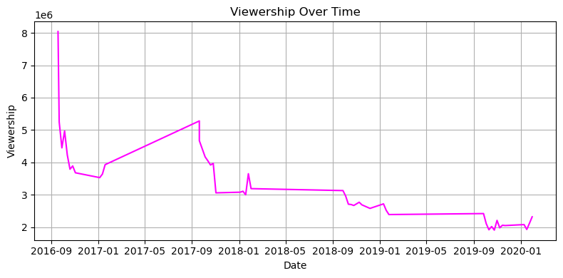

```python
df['original_air_date'] = pd.to_datetime(df['original_air_date'])

plt.figure(figsize=(8, 4))
plt.plot(df['original_air_date'], df['us_viewers'], linestyle='-',color= 'magenta' )
plt.title('Viewership Over Time')
plt.xlabel('Date')
plt.ylabel('Viewership')
plt.grid(True)
plt.tight_layout()
plt.show()
```

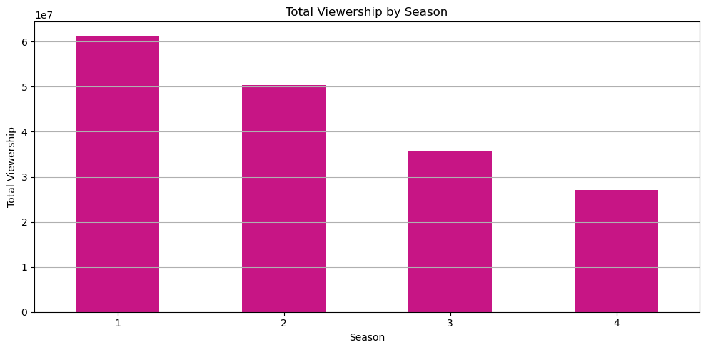

```python
# Ensure your season column is correctly formatted as categorical or integer
df['season'] = df['season'].astype(int)

# Calculate total viewership for each season
season_totals = df.groupby('season')['us_viewers'].sum()

# Plot the total viewership for each season
plt.figure(figsize=(10, 5))
season_totals.plot(kind='bar', color='#C71585')  # Dark pink color bars
plt.title('Total Viewership by Season')
plt.xlabel('Season')
plt.ylabel('Total Viewership')
plt.xticks(rotation=0)  # Horizontal x-axis labels for better readability
plt.grid(True, axis='y')
plt.tight_layout()
plt.show()
```

```python
# Calculate the change in viewership between seasons
season_change = season_totals.diff()

season_change
```

```
season
1           NaN
2   -10940000.0
3   -14740000.0
4    -8560000.0
Name: us_viewers, dtype: float64
```

The viwership decreased by **10940000** from season 1 to season 2, **14740000** from season 2 to season 3 and **8560000** from season 3 to season 4

Sources:

https://www.kaggle.com/datasets/bcruise/the-good-place-episode-data?resource=download

https://en.wikipedia.org/wiki/The_Good_Place